# Part II - (Data Analysis/Data Visualization Report on Ford GoBike System February, 2019)

## by (Cyril Ocloo)

## Investigation Overview

In this investigation, I will take a look at the bike ride trends and customer behaviour characteristics of the bay Area bike share system . I will specifically focus on how gender, age group, biking duration, the time (weekday, hour), and the user types impacts usage of the system.

## Dataset Overview

> The FordGobike dataset was collected efficiently and effectively and provides relevant features which is pretty easy to understand. The dataset uses data collected in different location in the San Francisco Bay area of California in the month February 2019. The dataset contains approximately 183400 bike riders infomation. The features included the trip start and end time, user type, gender, and age. The dataset had some missing values and outliers which was removed from the analysis.

## (Visualization 1)

## Number of bike trip by user type Visualization

Ford Gobike system has 2 user types. Users with a monthly membership/subscription known as ("Subscriber") make up 90% of all users in Feb 2019. On the other hand users ride casually of occationally known as ("Customer") constitute of 9% of all users.

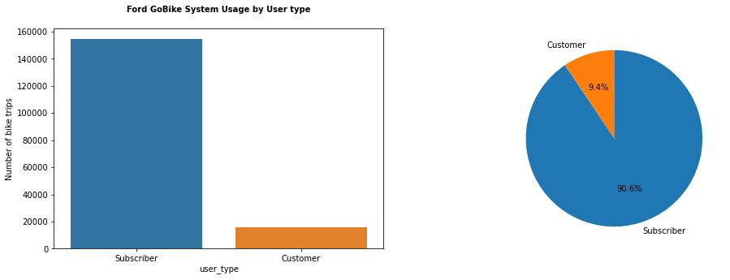

## (Visualization 2)

## Bike Usage by Duration time Visualization

From the visualization below, it can be observed that the pre transformed duration minutes data is skewed to the right with bikers duration minutes ranging form 1 to 99 minutes, a mean of 10 minutes and median of 8 minutes.

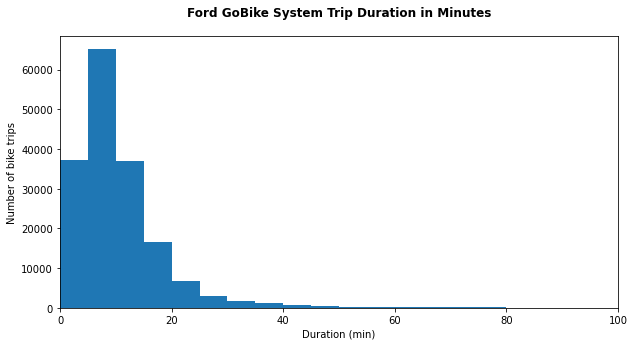

The data is then transformed to make data visualization and data interpretation easier. A log scale transformation is used.

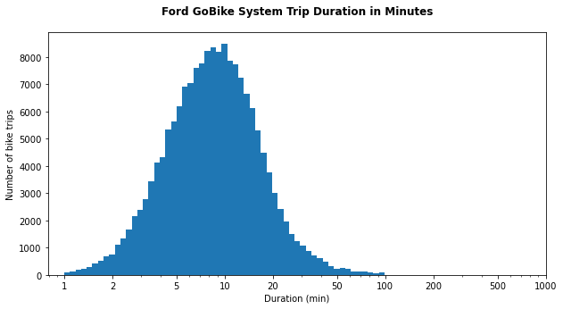

## (Visualization 3)

### Daily bike usage by user type Visualization

Features investigated include the following: Start Time Hour, User Type, Member Age Group, Member Gender and Start Time DayofWeek.

- Thursday records the highest number of bike trips for both customers and subscribers
- Most subscribers user the bike system usually at 8 am and 5 pm, while customers usualy ride the bikes at 5 pm.
- Subscribers and customers who fall within the age group of 26-35 years old use the Gobike sharing system more.
- Customers of all age group (except 46-60) turn to use the Gobike system more over the weekend which is explained by the increase in number of bike trips from Saturday to Sunday
- Both male subscribers and customers ride the bikes more.
- Both female customers and subscribers take longer trips than other genders even though male subscribers and customers take more trips.
- Customers who fall within the age group of 15-25 years old take longer bike trips than other age groups while subscribers who fall within the age group of 46-60 years old take longer bike trips than other age groups.

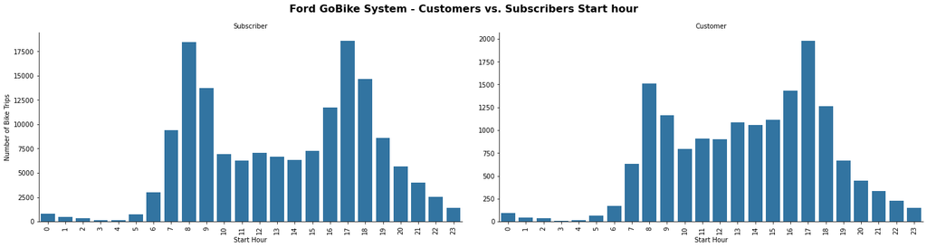

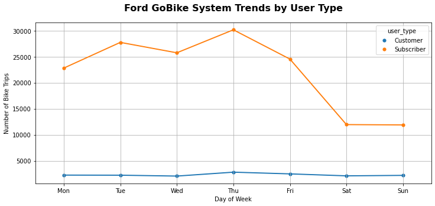

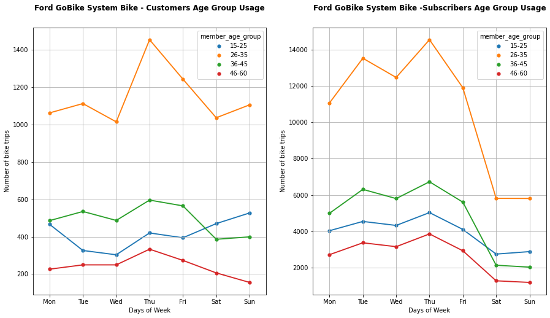

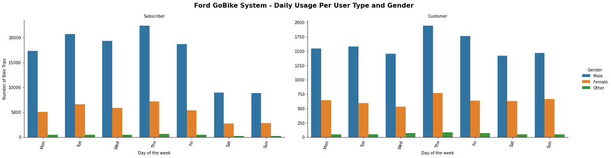

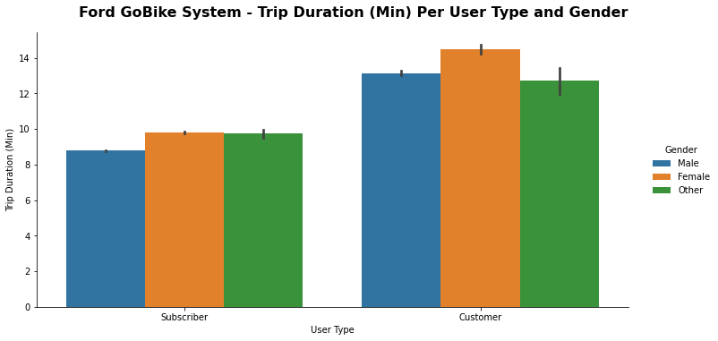

[figure not shown]